# SDS 315 Homework 3

### Theory C - Gas stations at stoplights charge more

```
##       name       lower      upper level     method     estimate
## 1 diffmean -0.03806622 0.03061644  0.95 percentile -0.003299916
```

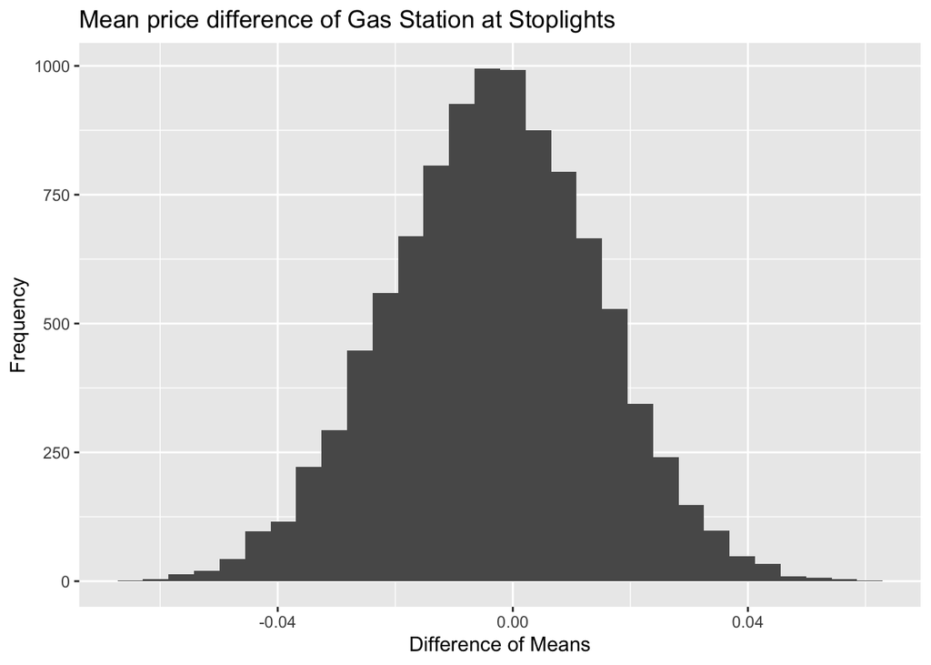

We are trying to see if gas stations at stop lights charge the gas price higher than those not at stop lights.The evidence behind this claim does not support the argument as the the 95% confidence interval has 0 which means this results are not statistically significant. Also the difference in price is only around 0 cents, emphasizing that this theory is not supported by our data.

### Theory D - Gas stations with direct highway access charge more

```
##       name       lower      upper level     method  estimate
## 1 diffmean 0.009021154 0.08202915  0.95 percentile 0.0456962
```

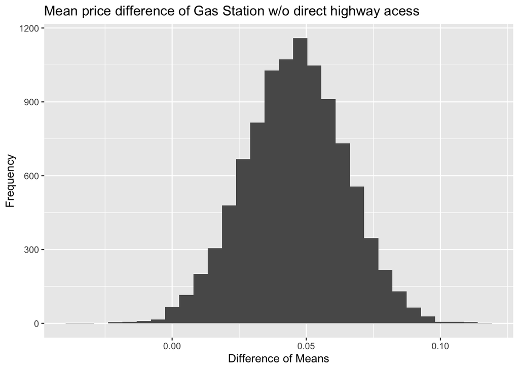

We are trying to see if gas stations at highways with direct access charge the gas price higher than those not at direct highway access lights.The evidence behind this claim does support the argument as the the 95% confidence interval does not include the value 0 which means these results are statistically significant. Also the difference in price is around 4.6 cents, emphasizing that this theory is supported by our data.

### Theory E - Shell charges more than all other non-Shell brands.

```
##       name       lower      upper level     method   estimate
## 1 diffmean -0.00975884 0.06528371  0.95 percentile 0.02740421
```

```
##    FALSE     TRUE
## 1.856389 1.883793
```

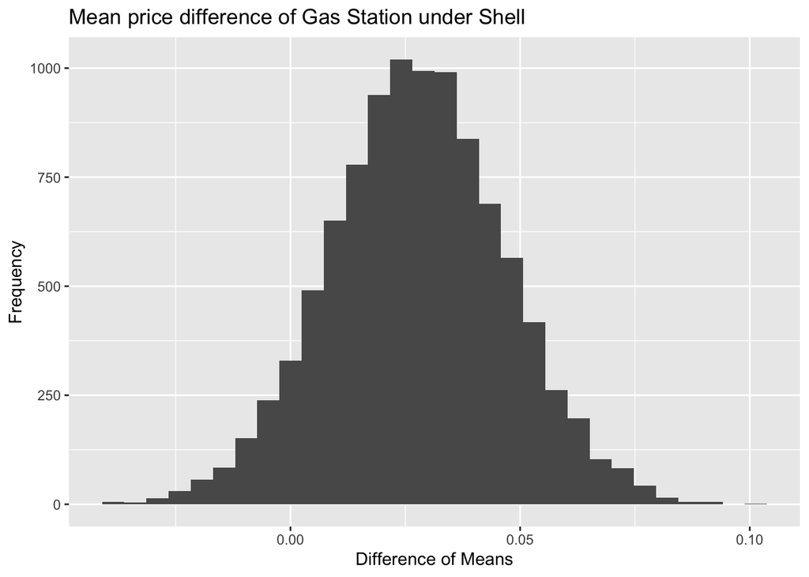

We are trying to see if gas stations under the brand Shell charge higher than other brands in the same market .The evidence behind this claim does not support the argument as the the 95% confidence interval has 0 which means this results are not statistically significant. Also the difference in price is only around 2.7 cents, emphasizing that this theory is not supported by our data given.

## Question 2

### Part A

```
##   name    lower    upper level     method estimate
## 1 mean 26283.31 31882.54  0.95 percentile 28997.34
```

### Part B

[output not shown]